# Modern Data Mining, HW 1

Mahika Calyanakoti

Graham Branscom

Andrew Raine

Due: 11:59PM, Feb 4th, 2024

# 1 Overview

This is a fast-paced course that covers a lot of material. There will be a large amount of references. You may need to do your own research to fill in the gaps in between lectures and homework/projects. It is impossible to learn data science without getting your hands dirty. Please budget your time evenly. Last-minute work ethic will not work for this course.

Homework in this course is different from your usual homework assignment as a typical student. Most of the time, they are built over real case studies. While you will be applying methods covered in lectures, you will also find that extra teaching materials appear here. The focus will be always on the goals of the study, the usefulness of the data gathered, and the limitations in any conclusions you may draw. Always try to challenge your data analysis in a critical way. Frequently, there are no unique solutions.

Case studies in each homework can be listed as your data science projects (e.g. on your CV) where you see fit.

## 1.1 Objectives

- Get familiar with `R-studio` and `RMarkdown`
- Hands-on R
- Learn data science essentials
  - gather data
  - clean data
  - summarize data
  - display data
  - conclusion
- Packages
  - `dplyr`
  - `ggplot`

## 1.2 Instructions

- **Homework assignments can be done in a group consisting of up to three members**. Please find your group members as soon as possible and register your group on our Canvas site.
- **All work submitted should be completed in the R Markdown format.** You can find a cheat sheet for R Markdown [here](https://www.rstudio.com/wp-content/uploads/2015/02/rmarkdown-cheatsheet.pdf) For those who have never used it before, we urge you to start this homework as soon as possible.
- **Submit the following files, one submission for each group:** (1) Rmd file, (2) a compiled HTML or pdf version, and (3) all necessary data files if different from our source data. You may directly edit this .rmd file to add your answers. If you intend to work on the problems separately within your group, compile your answers into one Rmd file before submitting. We encourage that you at least attempt each problem by yourself before working with your teammates. Additionally, ensure that you can ‘knit’ or compile your Rmd file. It is also likely that you need to configure Rstudio to properly convert files to PDF. [**These instructions**](http://kbroman.org/knitr_knutshell/pages/latex.html#converting-knitrlatex-to-pdf) might be helpful.
- In general, be as concise as possible while giving a fully complete answer to each question. All necessary datasets are available in this homework folder on Canvas. Make sure to document your code with comments (written on separate lines in a code chunk using a hashtag `#` before the comment) so the teaching fellows can follow along. R Markdown is particularly useful because it follows a ‘stream of consciousness’ approach: as you write code in a code chunk, make sure to explain what you are doing outside of the chunk.
- A few good or solicited submissions will be used as sample solutions. When those are released, make sure to compare your answers and understand the solutions.

## 1.3 Review materials

- Study Basic R Tutorial
- Study Advanced R Tutorial (to include `dplyr` and `ggplot`)
- Study lecture 1: Data Acquisition and EDA

# 2 Case study 1: Audience Size

How successful is the Wharton Talk Show [Business Radio Powered by the Wharton School](https://businessradio.wharton.upenn.edu/)

**Background:** Have you ever listened to [SiriusXM](https://www.siriusxm.com/)? Do you know there is a **Talk Show** run by Wharton professors in Sirius Radio? Wharton launched a talk show called [Business Radio Powered by the Wharton School](https://businessradio.wharton.upenn.edu/) through the Sirius Radio station in January of 2014. Within a short period of time the general reaction seemed to be overwhelmingly positive. To find out the audience size for the show, we designed a survey and collected a data set via MTURK in May of 2014. Our goal was to **estimate the audience size**. There were 51.6 million Sirius Radio listeners then. One approach is to estimate the proportion of the Wharton listeners to that of the Sirius listeners, $p$, so that we will come up with an audience size estimate of approximately 51.6 million times $p$.

To do so, we launched a survey via Amazon Mechanical Turk ([MTurk](https://www.mturk.com/)) on May 24, 2014 at an offered price of $0.10 for each answered survey. We set it to be run for 6 days with a target maximum sample size of 2000 as our goal. Most of the observations came in within the first two days. The main questions of interest are “Have you ever listened to Sirius Radio” and “Have you ever listened to Sirius Business Radio by Wharton?”. A few demographic features used as control variables were also collected; these include Gender, Age and Household Income.

We requested that only people in United States answer the questions. Each person can only fill in the questionnaire once to avoid duplicates. Aside from these restrictions, we opened the survey to everyone in MTurk with a hope that the sample would be more randomly chosen.

The raw data is stored as `Survey_results_final.csv` on Canvas.

## 2.1 Data preparation

1. We need to clean and select only the variables of interest.

Select only the variables Age, Gender, Education Level, Household Income in 2013, Sirius Listener?, Wharton Listener? and Time used to finish the survey.

Change the variable names to be “age”, “gender”, “education”, “income”, “sirius”, “wharton”, “worktime”.

2. Handle missing/wrongly filled values of the selected variables

As in real world data with user input, the data is incomplete, with missing values, and has incorrect responses. There is no general rule for dealing with these problems beyond “use common sense.” In whatever case, explain what the problems were and how you addressed them. Be sure to explain your rationale for your chosen methods of handling issues with the data. Do not use Excel for this, however tempting it might be.

Tip: Reflect on the reasons for which data could be wrong or missing. How would you address each case? For this homework, if you are trying to predict missing values with regression, you are definitely overthinking. Keep it simple.

### 2.1.1 How we handled missing values.

3. Brief summary

Write a brief report to summarize all the variables collected. Include both summary statistics (including sample size) and graphical displays such as histograms or bar charts where appropriate. Comment on what you have found from this sample. (For example - it’s very interesting to think about why would one work for a job that pays only 10cents/each survey? Who are those survey workers? The answer may be interesting even if it may not directly relate to our goal.)

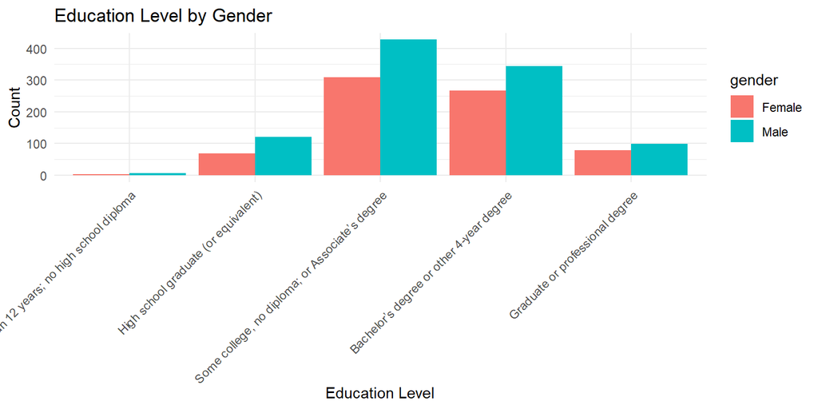

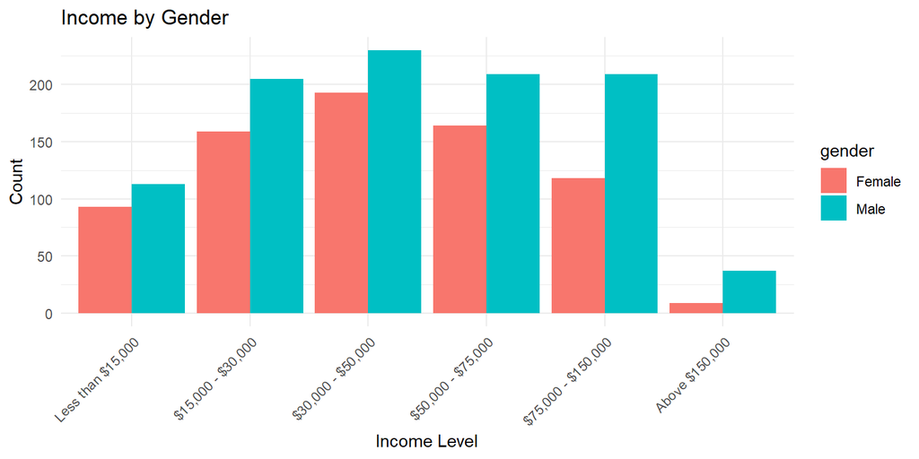

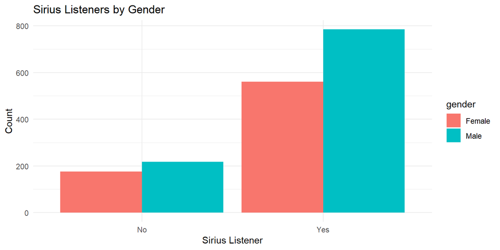

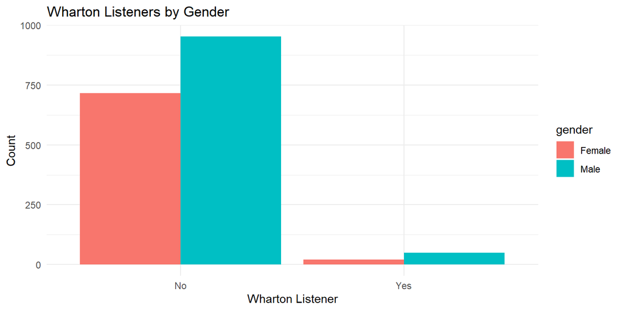

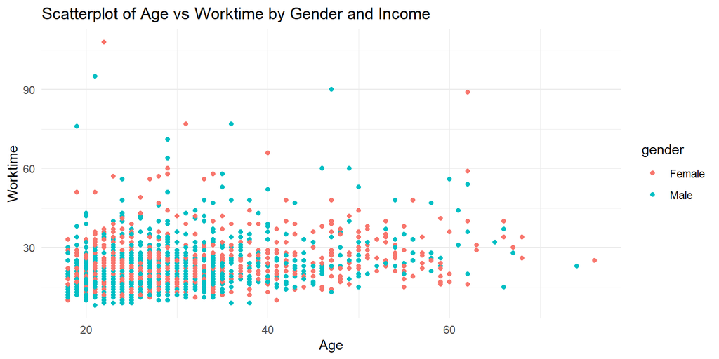

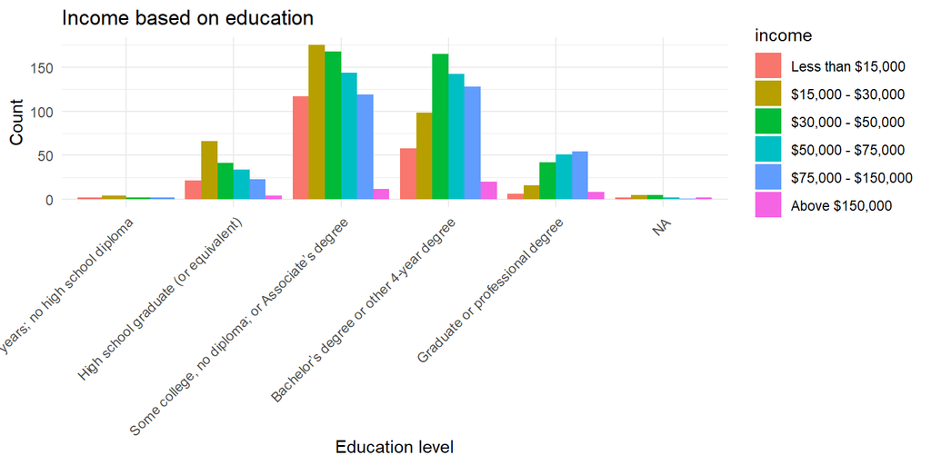

### 2.1.2 Comments from visualizations

The education level follows roughly a normal distribution, where most respondents’ education level was some college or a bachelor’s degree. This pattern was the same across both genders.

The income level among females was moreso a normal distribution compared to that of the men. The females centered around $30-50k, whereas the males plateaued from $15-30k to $75-150k. Thus, the men are more represented among the higher income brackets. The mode (i.e. most commonly chosen income bracket) was $30-50k (424 respondents), which suggests that these survey workers were motivated by the 10 cent incentive because they have an income lower than the mean household income in the US.

Additionally, most respondents were Sirius listeners ($\frac{1345}{1739}$) and the majority of the Sirius listeners are men. Almost all respondents are not Wharton listeners ($\frac{70}{1739}$).

In our income vs education graph, as the education level increases, the median income level tends to shift from right to left (from lower to higher income).

## 2.2 Sample properties

The population from which the sample is drawn determines where the results of our analysis can be applied or generalized. We include some basic demographic information for the purpose of identifying sample bias, if any exists. Combine our data and the general population distribution in age, gender and income to try to characterize our sample on hand.

1. Does this sample appear to be a random sample from the general population of the USA? Why it is crucial to have randomness here?

Overall, the data is not very representative of the general US population.

Data sources: https://www.nytimes.com/2023/06/22/us/census-median-age.html, https://www.census.gov/library/publications/2023/demo/p60-279.html

It is crucial to have randomness here because if we want to use this survey to inform how the radio show markets to audiences or use this data to inform other radio shows, it is crucial to have data that mimics the overall US.

2. Does this sample appear to be a random sample from the MTURK population?

Overall, the sample does not appear to be a completely random sample of the MTURK population. The survey respondents are younger (median 28 years-old) than the MTURK population (median ~50-59 years-old). We have majority male (~58%), whereas MTURK is majority female (~58%). The MTURK population has a higher representation of higher income brackets compared to our data. For instance, two of the most common income brackets among the MTURK population is $50-60k and $100-150k.

We used the following link for MTURK population demographics data: (https://www.cloudresearch.com/resources/blog/who-uses-amazon-mturk-2020-demographics/).

Note: You can not provide evidence by simply looking at our data here. For example, you need to find distribution of education in our age group in US to see if the two groups match in distribution. You may need to gather some background information about the MTURK population to have a slight sense if this particular sample seem to a random sample from there… Please do not spend too much time gathering evidence.

## 2.3 Final estimate

Give a final estimate of the Wharton audience size by May of 2014. Assume that the sample is a random sample of the MTURK population, and that the proportion of Wharton listeners vs. Sirius listeners in the general population is the same as that in the MTURK population. Write a brief executive summary to summarize your findings and how you came to that conclusion.

To be specific, you should include:

### 2.3.1 1. Goal of the study

The goal of the study is to estimate the audience size for Wharton Business Radio on the Sirius radio station using the results from an MTURK survey of under 2000 respondents in May 2014. We also aimed to collect demographic information about the survey respondents and see the relationship between the demographic variables.

### 2.3.2 2. Method used: data gathering, estimation methods

We used an Amazon MTURK survey to gather data. We then used na.omit() to clean the data and then removed outliers. We also cleaned the data by converting to the factor data type to categorize the data. We made histograms and scatterplots to see the relationship between variables like education vs. income. We also used ggplot() and functions like summary() to visualize and summarize the data.

### 2.3.4 4. Limitations of the study.

The main limitation of the study was that it was not representative of the US and MTURK populations. Additionally, the median age is 28, but the median age in the US is 38 years-old. For instance, we have majority male (~58%), whereas MTURK is majority female (~58%). Similar differences were seen for the other variables like education and income. This is a limitation because we want our survey data to be able to represent the overall populations so that we can better understand who the radio audience is.

The survey itself is also limited because it does not ask other information like how often they listen, how long they listen to shows, how long they have been listening to the radio, etc. The survey could also collect info on how the respondents would rate their experience listening to the Wharton Business Radio show and the radio in general.

## 2.4 New task

We are asked to design a study to estimate the audience size of Wharton Business Radio Show as of today. We are given a budget of $1000 and need to present your findings in two months. Here is our methodology.

### 2.4.1 1. Method proposed to estimate the audience size.

#### 2.4.1.1 Survey Platform:

We plan to use the Prolific survey distribution website, which thoroughly vets its respondents using their IDs. This mitigates the issue of fake large language model responses that we have observed in previous surveys using MTurk, which has a lower bar for respondent entry.

#### 2.4.1.2 Survey Demographic Filtering:

We plan to use Prolific’s option of getting a high quality, nationally representative sample of responses. Here is their article about the feature, which compares their sample population with that of the US Census and other large-scale surveys.

#### 2.4.1.3 Target Sample Size:

Given our budget of $1000, an estimated survey completion time of 1 minute, and a target hourly rate of $10/hour/respondent, our estimated maximum number of responses is $\frac{1000}{10/60}=6000$. We can iteratively collect and analyze the responses until we have a USA representative sample size; the representation validity check is outlined below. By iteratively collecting and analyzing, we can minimize the costs required to accurately estimate the viewership population.

#### 2.4.1.4 Data to Collect:

- Whether the respondent listens to the Wharton Business Radio Show.
- The respondent’s sex.
- The respondent’s age.
- The respondent’s race.

#### 2.4.1.5 Data Integrity Checks:

After compiling all survey responses, we can 1. Calculate the sex, age, and race distributions for our 6000 samples. 2. Calculate the sex, age, and race distributions for the publicly available US Census dataset. 3. Check if those our sample distributions match that of the US Census. If not, we may randomly sub-sample our sample dataset to match the distribution of the broader USA. An example: say our data is skewed towards an older population than the US census. We may compute the proportion of the population in each year bracket from the Census data, then randomly subsample our own dataset to match that distribution. 4. Compute the proportion of our sample that watches the Wharton Business Radio Show, and then multiply it by the number of people in the USA to arrive at our final estimate.

# 3 Case study 2: Women in Science

Are women underrepresented in science in general? How does gender relate to the type of educational degree pursued? Does the number of higher degrees increase over the years? In an attempt to answer these questions, we assembled a data set (`WomenData_06_16.xlsx`) from [NSF](https://ncses.nsf.gov/pubs/nsf19304/digest/field-of-degree-women) about various degrees granted in the U.S. from 2006 to 2016. It contains the following variables: Field (Non-science-engineering (`Non-S&E`) and sciences (`Computer sciences`, `Mathematics and statistics`, etc.)), Degree (`BS`, `MS`, `PhD`), Sex (`M`, `F`), Number of degrees granted, and Year.

Our goal is to answer the above questions only through EDA (Exploratory Data Analyses) without formal testing. We have provided sample R-codes in the appendix to help you if needed.

## 3.1 Data preparation

1. Understand and clean the data

Notice the data came in as an Excel file. We need to use the package `readxl` and the function `read_excel()` to read the data `WomenData_06_16.xlsx` into R.

a). Read the data into R.

b). Clean the names of each variables. (Change variable names to `Field`,`Degree`, `Sex`, `Year` and `Number` )

c). Set the variable natures properly.

d). Any missing values?

There are no missing/NA values.

2. Write a summary describing the data set provided here.

a). How many fields are there in this data?

b). What are the degree types?

There are 3 degree types: BS, MS, PhD.

c). How many year’s statistics are being reported here?

There are 11 unique years. (2006 to 2016 contains 11 unique years)

## 3.2 BS degrees in 2015

Is there evidence that more males are in science-related fields vs `Non-S&E`? Provide summary statistics and a plot which shows the number of people by gender and by field. Write a brief summary to describe your findings.

Based on the plot below which shows the results of the frequency of each gender for S&E vs Non S&E fields, we can see the following:

Visualization 1: Females by far dominate in the Non S&E category, while males are slightly more represented when evaluating the S&E category. This provides evidence that more males are in science-related fields vs `Non-S&E`.

[output not shown]

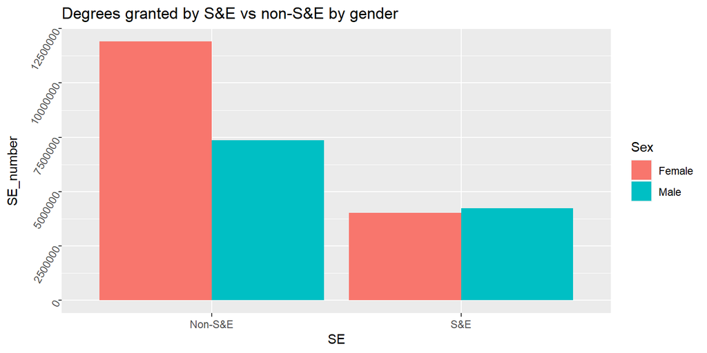

Based on the plot below, we can see the following:

Visualization 2: Females are the majority (over 60%) of Non S&E jobs pretty consistently across the years, and have been taking an even greater proportion in recent years (upwards trend in 2014-2016). However, they are only a smaller fraction of S&E jobs (below 50%) pretty consistently, and have been even less represented in recent years (downward trend in 2014-2016).

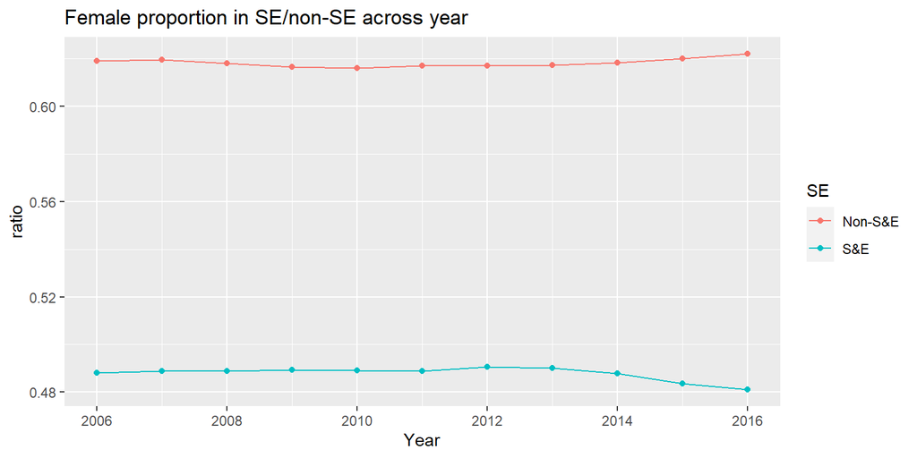

## 3.3 EDA bringing type of degree, field and gender in 2015

Based on the plot below that shows the frequency of each gender for each field, we can see the following:

Visualization 3: Males are more represented in the computer science and engineering fields, where as females are more represented in the Non S&E fields. Females are higher in fields like psychology and social science. For instance, in Engineering PhDs, males have 7500 degrees, whereas females have just 2500 degrees; in contrast, in Non S&E PhD degrees, males have just over 10000 degrees whereas females have way more: 17500 degrees.

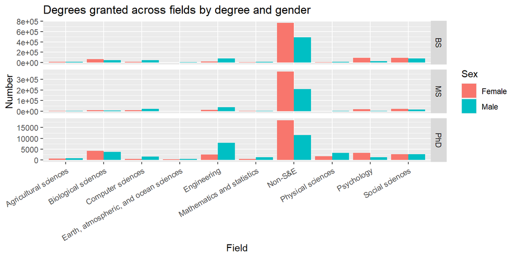

Describe the number of people by type of degree, field, and gender. Do you see any evidence of gender effects over different types of degrees? Again, provide graphs to summarize your findings.

Based on the plot below that shows the number of people by type of degree, field, and gender, we can see the following:

Visualization 4: In the BS category for Non S&E fields, we see an much steeper upwards trend in females when compared to males, which suggested there is increasingly more female representation in Non S&E fields. The upwards trends for BS in S&E fields seems relatively alike. In the masters category, there is a dominance of females in the Non S&E fields, whereas for masters in S&E fields, we see the males overpowering increasingly, especially in recent years. In the PhD category, we see very consistent trends over time where females have more Non S&E PhDs, where as the males are more in the S&E PhD category.

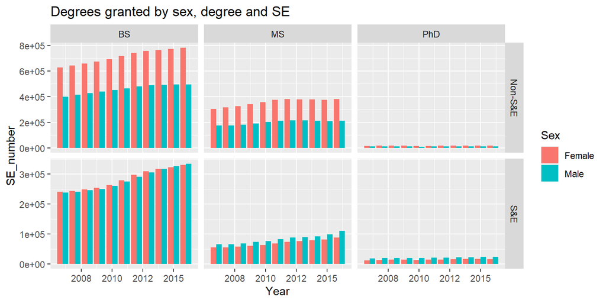

Based on the two plots below, we can see the following:

Visualization 5 (Female proportion in SE/non-SE across year by degree): As the type of degree becomes higher and higher in education level, we see less ratio of females in S&E degrees across the years. In recent years, the gap between the ratio of females in non S&E jobs and the ratio of females in S&E jobs is widening. For instance, in Masters in S&E degrees from 2014-2016 we see a downwards trend. The least stable trend over the years is the ratio of females in Non S&E PhDs, which has shown a lot of fluctuation, but shows an upwards trend in recent years.

Visualization 6 (Degrees granted proportion by sex across degree and SE): We can see that in all of the Non S&E categories, we have a higher percentage of females, where as the opposite is true (males dominate, except for in BS which is almost 50/50 split) in the S&E categories across degree type

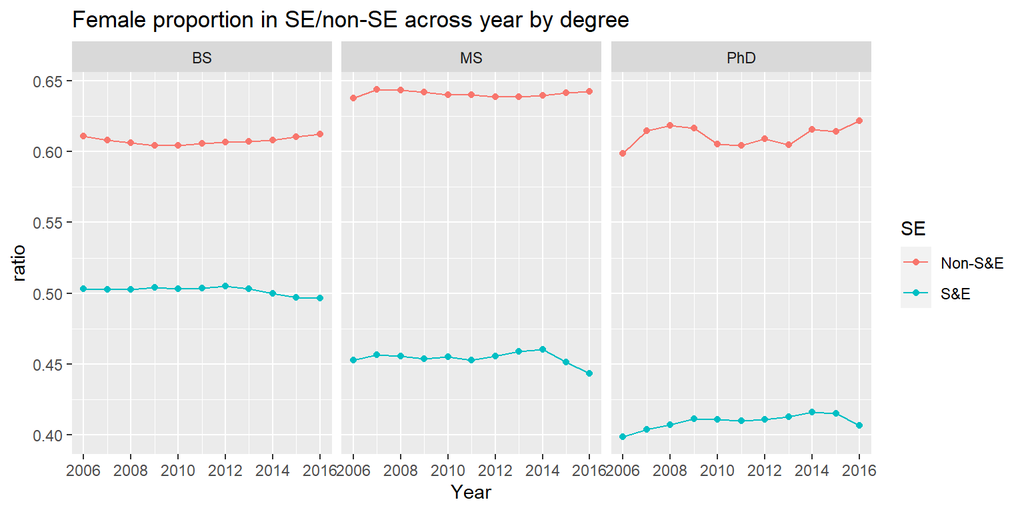

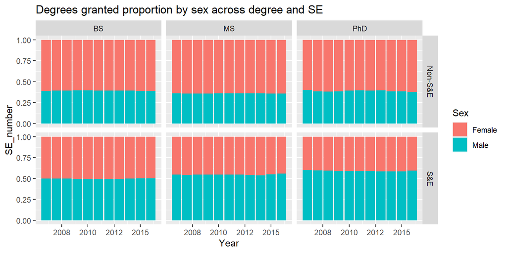

## 3.4 EDA bring all variables

In this last portion of the EDA, we ask you to provide evidence numerically and graphically: Do the number of degrees change by gender, field, and time?

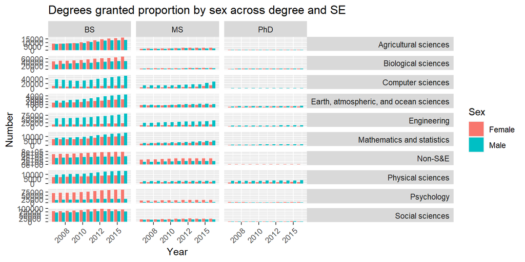

## 3.5 Women in Data Science

Finally, is there evidence showing that women are underrepresented in data science? Data science is an interdisciplinary field of computer science, math, and statistics. You may include year and/or degree.

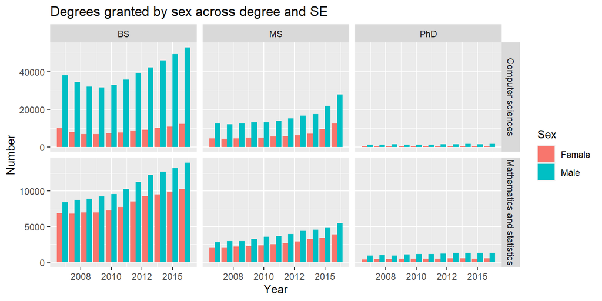

## 3.6 Final brief report

Summarize your findings focusing on answering the questions regarding if we see consistent patterns that more males pursue science-related fields. Any concerns with the data set? How could we improve on the study?

DATA: The data seen in the study, called `WomenData_06_16.xlsx` from [NSF](https://ncses.nsf.gov/pubs/nsf19304/digest/field-of-degree-women) provides information from the years 2006 to 2016, specifically in the US. It contains data about the number of degrees in specific fields, for specific types of degrees (BS, MS, PhD), by gender, and shows these trends by containing information about the number of degrees granted across these 11 years.

GOAL OF THE STUDY: The question at hand was to see if women were underrepresented in certain fields, namely in science/engineering fields. The analysis explores how there might be different trends in the types of degrees pursued based on gender over the years.

METHODS: This case study utilizes EDA (Exploratory Data Analysis) to collect summary statistics (like mean, median, standard deviation, frequency, etc. across variables). We use grouping to analyze the data, specifically using factor data-type columns for this analysis. We also use the year column to analyze trends over time.

We saw that in all of the Non S&E categories, we have a higher percentage of females, where as the opposite is true (males dominate, except for in BS which is almost 50/50 split) in the S&E categories across degree type. Males are more represented in the computer science and engineering fields, where as females are more represented in the Non S&E fields. Females are higher in fields like psychology and social science. For instance, in Engineering PhDs, males have 7500 degrees, whereas females have just 2500 degrees; in contrast, in Non S&E PhD degrees, males have just over 10000 degrees whereas females have way more: 17500 degrees.

These trends show that over time, we have seen an increase in males in science and engineering degrees, such as math and statistics, while females tend to be underrepresented in these fields especially in higher degrees such as MS and PhD when analyzing the data over time from 2006 to 2016.

WAYS TO IMPROVE: The data set is actually very fair and minimally biased in terms of the data collected. There are 330 females and 330 males, and the number of data points collected per fields are all 66, and the number of data points collected per degree type was also 220 for each BS, MS, and PhD. In this way, the data doesn’t seem to be skewed one way or another. The study can be improved by analyzing data over a longer period of time, and also by collecting more recent data. The data can include some more variables, such as information about people dropping out of degrees, and potentially can be extended to analyze salary/pay by gender based on the degree field/type that the person received. This might show more robust results and analyses.

## 3.7 Appendix

To help out, we have included some R-codes here as references. You should make your own chunks filled with texts going through each items listed above. Make sure to hide the unnecessary outputs/code etc.

1. Clean data
2. A number of sample analyses

# 4 Case study 3: Major League Baseball

We would like to explore how payroll affects performance among Major League Baseball teams. The data is prepared in two formats record payroll, winning numbers/percentage by team from 1998 to 2014.

Here are the datasets:

-`MLPayData_Total.csv`: wide format -`baseball.csv`: long format

Feel free to use either dataset to address the problems.

## 4.1 EDA: Relationship between payroll changes and performance

Payroll may relate to performance among ML Baseball teams. One possible argument is that what affects this year’s performance is not this year’s payroll, but the amount that payroll increased from last year. Let us look into this through EDA.

Create increment in payroll a). To describe the increment of payroll in each year there are several possible approaches. Take 2013 as an example:

```
- option 1: diff: payroll_2013 - payroll_2012
- option 2: log diff: log(payroll_2013) - log(payroll_2012)
```

Explain why the log difference is more appropriate in this setup.

The log difference calculates the percentage change between the two years, so that we can see the proportional difference instead of the absolute difference.

b). Create a new variable `diff_log=log(payroll_2013) - log(payroll_2012)`. Hint: use `dplyr::lag()` function.

c). Create a long data table including: team, year, diff_log, win_pct

## 4.2 Exploratory questions

a). Which five teams had highest increase in their payroll between years 2010 and 2014, inclusive?

By computing the sum of the log increase in payroll from 2010 to 2014 (inclusive), we found the cumulative log difference in payroll increases. Using this method, we found that the five teams with the highest increase in their payroll changes were, in descending order: Los Angeles Dodgers, Washington Nationals, San Diego Padres, Texas Rangers, and San Francisco Giants.

b). Between 2010 and 2014, inclusive, which team(s) “improved” the most? That is, had the biggest percentage gain in wins?

The Pittsburgh Pirates and the Baltimore Orioles had the greatest win improvement, followed by the Washington Nationals and Seattle Mariners, and finally the Kansas City Royals and Los Angeles Angels.

## 4.3 Do log increases in payroll imply better performance?

Is there evidence to support the hypothesis that higher increases in payroll on the log scale lead to increased performance?

Pick up a few statistics, accompanied with some data visualization, to support your answer.

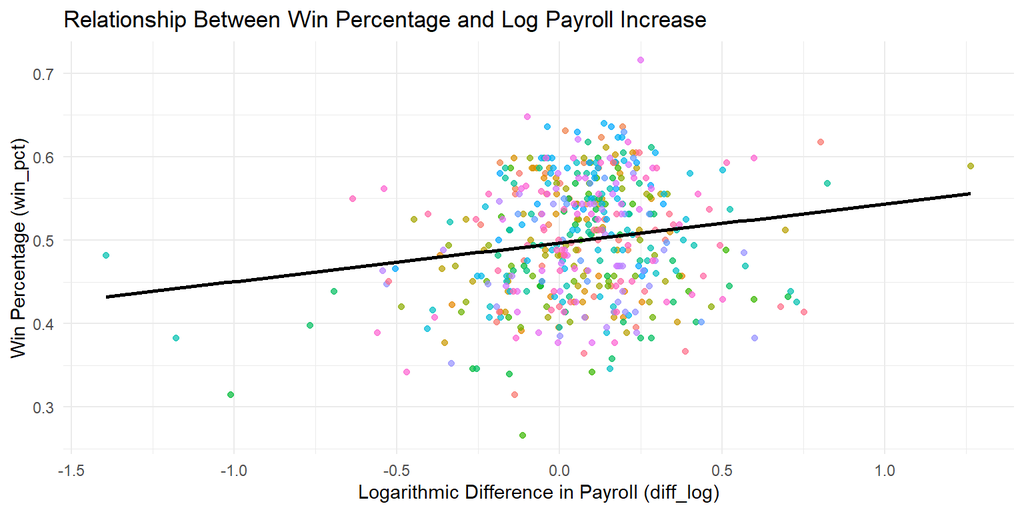

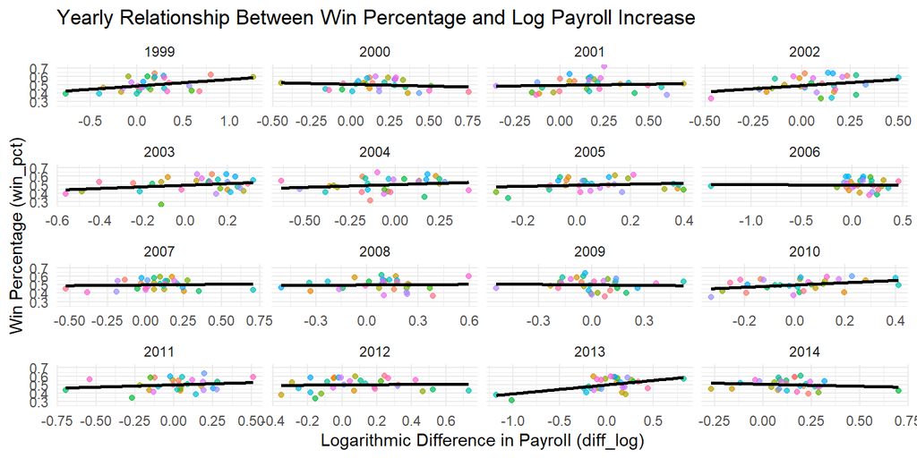

## 4.4 Comparison

Which set of factors are better explaining performance? Yearly payroll or yearly increase in payroll? What criterion is being used?

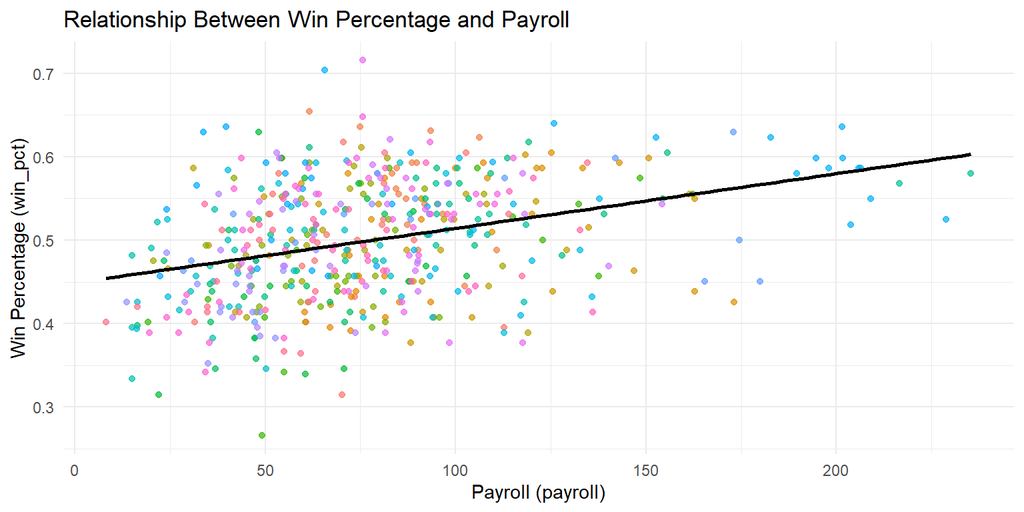

### 4.4.1 DATA

We used baseball.csv, which is a data set that contains information about various baseball teams’ payroll and win percentages/win number across time from 1998 to 2014.

### 4.4.2 GOAL/QUESTION

We want to explore the relationship between payroll and win percentage, versus seeing if analyzing this relationship is better to do when calculating the difference in payroll between years rather than the payroll of the current year itself.

### 4.4.3 METHODS

We use EDA to analyze the data and the summary of the variables. We also create a new table column called diff_log to analyze the difference of the log of the payroll for each year, which allows us to analyze the proportional rather than absolute difference between payrolls across the year. We also make the table long data, since that is better practice than using wide data.

### 4.4.5 LIMITATIONS

Sometimes payroll increase doesn’t mean the same thing for all of the teams. For instance, the NY Yankees are already so good and already have so much money that an increase in some amount of money would look like a small percentage increase, whereas that same amount of money would be a larger percentage for teams with less money to begin with like the Pittsburgh Pirates. Better teams probably don’t need more money to do well since they are already so good, while worse teams might not be able to be more competitive even if they did gain more money.